# Exploring Count Regression

Poisson and Negative Binomial Models in Physician Visits

Author

Michaela Luceno

# 1. Loading Data

## 1.2 Looking at Variables

Our reference variable for the health category is **Average** and **Male** for the gender category.

```
     n     mean      var    p_zero max
1 4406 5.774399 45.68712 0.1550159  89
```

[figure not shown]

Upon initially analyzing the data, it can be observed that it is count data; all values are whole numbers being 0 or higher, and it presents a positive, right skew. The variance is 45.69 is about 7.91 times the mean 5.77. This data is very overdispersed and there’s more spread than Poisson would assume, as Poisson assumes the variance is equal to the mean. In order to understand the count, we can see that **16%** have never visited the doctor. We would need to see if the model truly has this amount of zeros.

# 2. Specify Competing Models

## 2.1 Why not a linear model?

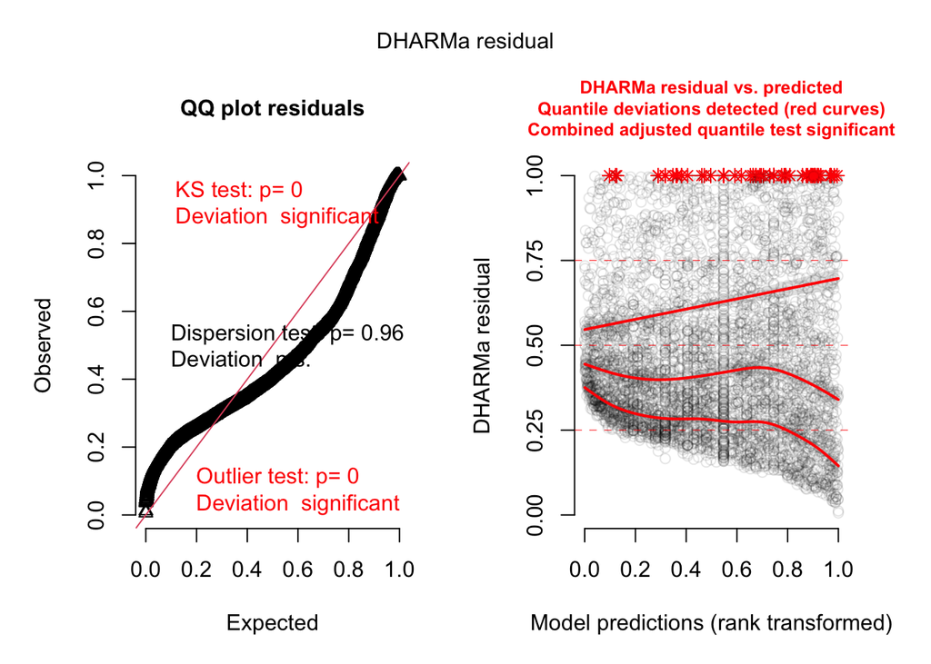

The function, DHARMa approximates new, predicted data from the fitted models and determining where the observed data is. If it was fitting the Gaussian model well, there would be uniform residuals along the QQ plot, however the shape notes that there is a cluster of low values near 0 and a cluster of higher values near 1. This linear model is not accurate predictive or representative of our count data. Deeper issues also lie, as Gaussian models can have negative counts with no bounds, however doctors visits in our data can’t be less than 0. It assumes a constant variance, however the variance grows with the mean, and Poisson predicts it is the same. Finally, it treats the effects as additive, however it’s more typical to multiply the count.

## 2.2 Specifying Nested Poisson Models

We are going to specify 3 nested models here. This means that there is an intercept model with only the outcome variable, and in each model, predictors are added.

| Model | Formula | Research rationale |
| --- | --- | --- |
| null: Null | `visits ~ 1` | Baseline model |
| one_predictor: Chronic | `visits ~ chronic` | Evaluate number of chronic conditions |
| Full Poisson: Full | `visits ~ chronic + health + gender + school + insurance` | The remaining predictors being conditions, health status, gender, education, and insurance explain additional variation |

## 2.2 Exploring and Comparing Fitted Models

Due to our models being nested, we can compare them all using an anova.

## 2.3 Combining Nested Test & Model Performance

## 2.4 Displaying the Combined Table

| Model | AIC | BIC | Log-likelihood | Deviance | Residual.df | Nested df | Nested χ² | Nested p |
| --- | --- | --- | --- | --- | --- | --- | --- | --- |
| Null | 39,720.340 | 39,726.731 | −19,859.170 | 26,942.921 | 4405 | — | — | — |
| One_Predictor: Chronic | 37,546.913 | 37,559.694 | −18,771.456 | 24,767.493 | 4404 | 1 | 2,175.428 | < .001 |
| Full | 36,596.989 | 36,641.724 | −18,291.494 | 23,807.569 | 4399 | 5 | 959.924 | < .001 |

## 2.5 Interpreting the combined table

The χ² value when looking between the null and a single predictor is 2175.43, with 1 df, and the p-value of < 0.001. When comparing the one predictor model to the full model, the χ² is 959.92, the df is 5, and the p-value is < 0.001.

The χ² statistic is the likelihood ratio, where the deviation will decrease with increased complexity as there are more factors as they account for more. The df accounts for how many parameters are being added, with the total number of variables being one more than the degrees of freedom. Finally, the p-value is the likelihood that that this is truly improvement if the simpler model were as good. We are going to be using he likelihood ratio value as a decision factor for the selected model, and the χ² value is 959.92 (p < 0.001), indicating significant improvement in fit. Therefore, our selected model is the **Full Poisson** model.

The provisionally selected model is **Full**, and the AIC value is **3.6596989^{4}**, and the BIC value is **3.6641724^{4}**.

# 3. Evaluating the Poisson Model

## 3.1 Simulating Residuals

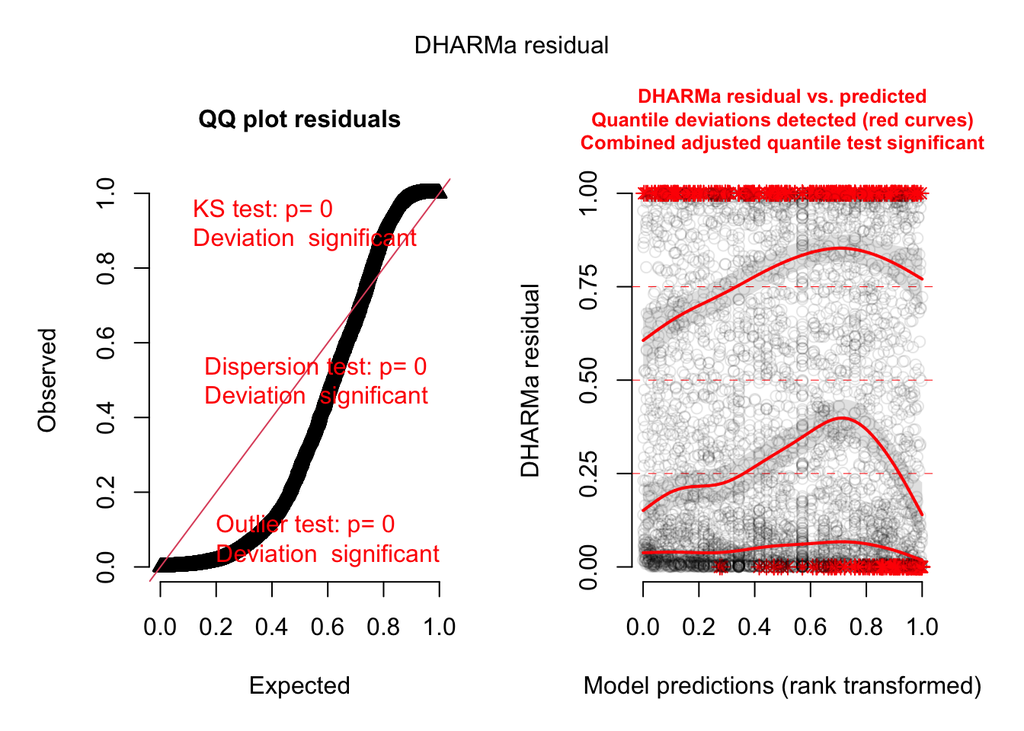

## 3.2 Testing for Overdispersion & Excess Zeros

This test will assess whether the observed variance is larger or smaller than our Poisson model would expect, and if there are more zeros than expected.

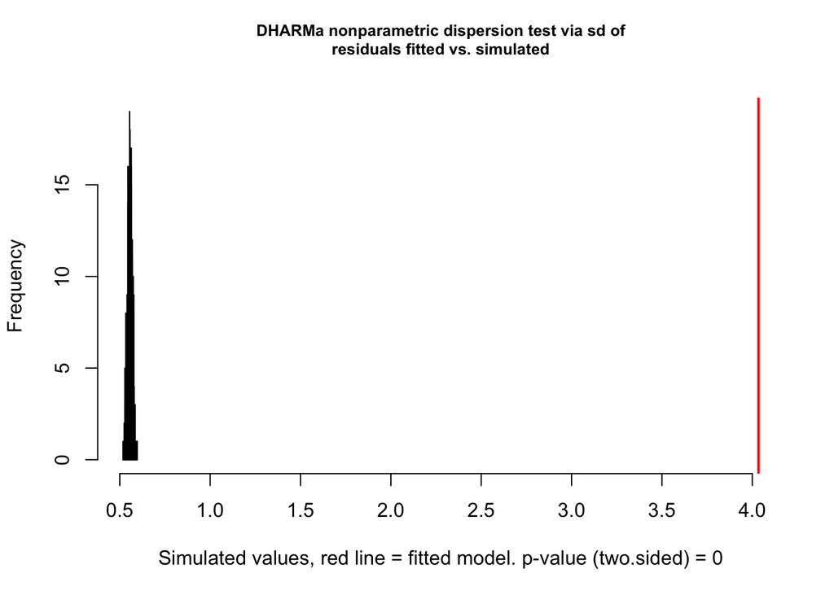

```
    DHARMa nonparametric dispersion test via sd of residuals fitted vs.
    simulated

data:  simulationOutput
dispersion = 7.2521, p-value < 2.2e-16
alternative hypothesis: two.sided
```

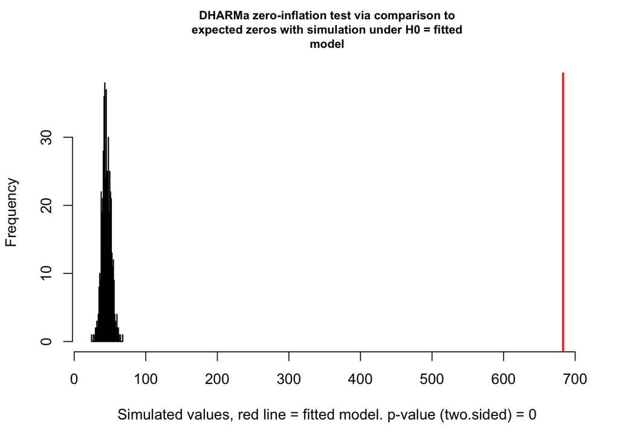

```
    DHARMa zero-inflation test via comparison to expected zeros with
    simulation under H0 = fitted model

data:  simulationOutput
ratioObsSim = 15.035, p-value < 2.2e-16
alternative hypothesis: two.sided
```

## 3.3 Interpreting the Diagnostics

The DHARMa plots suggest that the fit of the Poisson model is less than ideal. It can be seen that in both graphs, the values on the far left being the simulated values from the model are vastly different from the red line, being the actual values.

The dispersion ratio the plot has displayed is 7.25 (*p* < .001), and the expected rate of zero is 15.03 times the amount of zeros that the Poisson model expects, meaning that there is a greater variance in our data than the Poisson model can account for.

This overdispersion is important, as it carries the assumption that the variance is equal to the mean. Therefore, when this metric is incorrect, the other values that take into account the variance/mean, such as the standard errors, confidence intervals, and p-values, are also incorrect and likely decreased. We cannot, however move straight to a zero-inflated model after these results, as zeros can be generated from two processes: structural (individuals never visiting the physician office), or sampling (count process, where it’s sometimes zero).

# 4. Fit and Evaluate Negative Binomial Model

As the Poisson model did not fit well, we will be using a negative binomial model, which incorporates a dispersion parameter so that the variance is no longer equal to the mean. However, the Poisson model is still nested so that we can compare the two to assess which has better predictive ability (using a likelihood ratio test).

## 4.1 Estimate the NB2 Model

```
 Family: nbinom2  ( log )
Formula:          visits ~ chronic + health + gender + school + insurance
Data: data

      AIC       BIC    logLik -2*log(L)  df.resid
  24469.9   24521.0  -12227.0   24453.9      4398


Dispersion parameter for nbinom2 family (): 1.16

Conditional model:
                 Estimate Std. Error z value Pr(>|z|)
(Intercept)      0.825180   0.058565  14.090  < 2e-16 ***
chronic          0.195759   0.012475  15.692  < 2e-16 ***
healthpoor       0.367664   0.048204   7.627 2.40e-14 ***
healthexcellent -0.373645   0.061542  -6.071 1.27e-09 ***
genderfemale     0.115129   0.031658   3.637 0.000276 ***
school           0.027179   0.004402   6.174 6.67e-10 ***
insuranceyes     0.250155   0.040430   6.187 6.12e-10 ***
---
Signif. codes:  0 '***' 0.001 '**' 0.01 '*' 0.05 '.' 0.1 ' ' 1
```

## 4.2 Compare the Poisson and NB2

```
Data: data
Models:
poisson: visits ~ chronic + health + gender + school + insurance, zi=~0, disp=~1
neg_binom: visits ~ chronic + health + gender + school + insurance, zi=~0, disp=~1
          Df   AIC   BIC logLik deviance Chisq Chi Df Pr(>Chisq)
poisson    7 36597 36642 -18292    36583
neg_binom  8 24470 24521 -12227    24454 12129      1  < 2.2e-16 ***
---
Signif. codes:  0 '***' 0.001 '**' 0.01 '*' 0.05 '.' 0.1 ' ' 1
```

Using a Likelihood Ratio Test to compare the Poisson model versus the negative binomial model, the χ² was found to be (1) = 1.212908^{4}, *p* < .001. These values show that the addition of another parameter (through the df value), as seen in the large Chisq value, showing that the model fits better the the added parameter. Additionally, both the AIC and BIC (3.6597^{4} to 2.447^{4}, 3.6642^{4} to 2.4521^{4} respectively) were significantly lowered. Through these values, we can conclude that the NB2 model is a better fit. This added parameter was valuable in allowing the variance to exceed the mean, however these values cannot yet illustrate other problems such as extreme counts and excess zeros.

## 4.3 Double-Checking NB2 with DHARMa

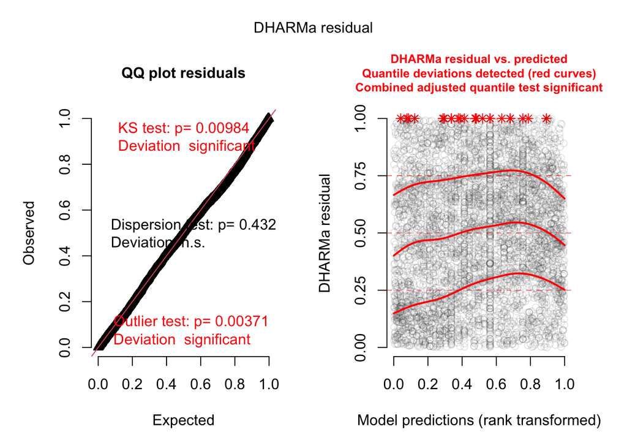

We would like to perform additional tests regarding the dispersion, as it becomes close to zero it indicates non-significance. We would also like to observe whether the model has produced a number of zeros similar to the observed, determining whether a hurdle or zero-inflated model might be needed.

In double checking these plots, the QQ plots should (and are) closer to the diagonal line, in which they are, showing the NB2 is adequate with residuals being closer to predicted. However, the DHARMa residual vs predicted illustrates that there is a curve rather than the expected flat, fitted line. This curvature looks to have a pattern, meaning that the residuals likely are not random (as they should be, which would create the ideal straight line); this illustrated systemic changes, which are not desirable in a model, and they do not match the horizontal, red quantile lines.

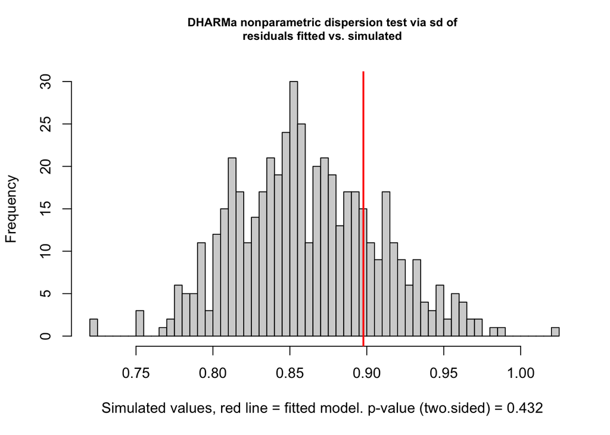

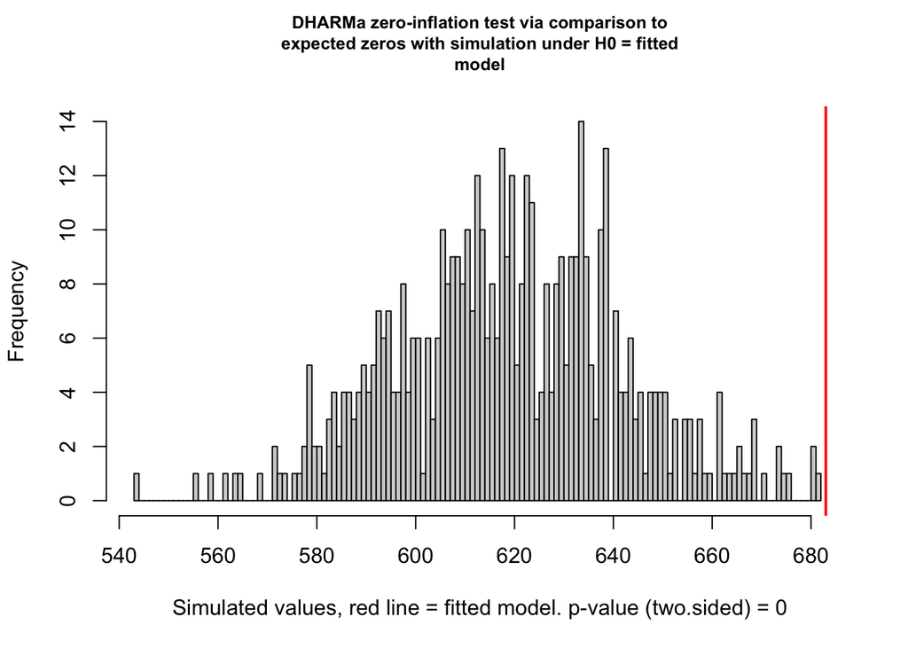

The negative binomial model has resolved overdispersion, as the ratio is now 1.04 (*p* = 0.432), and non-significant.

### Visualizing Predicted Counts

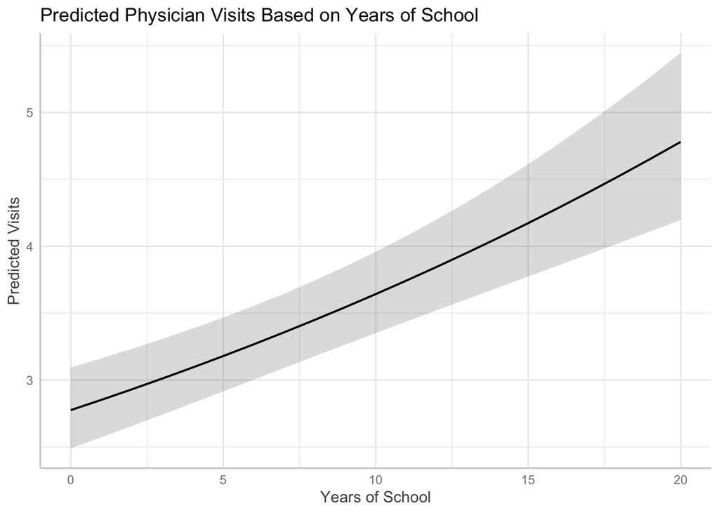

This model has created a curved line upwards, despite the predictors being linear, due to the use of a log link, as each year of school added isn’t 1, but rather the log of it, multiplying the expected count.

# 5. Do Zeros Need Their Own Model?

Are there more zeros than our model predicts?

Given our QQ plot and our residual versus predicted graph, we can see that the model does not provide a well-reproduced amount of zeros, as seen by the red line far towards the right of the simulated zeros, showing more zeros than expected (observed/expected = 1.1, *p* = 0). The other two models that could be used are the zero-inflated model (structured versus sampling) or the hurdle model (hurdle component, and the zero-truncated component).

```
Data: data
Models:
neg_binom: visits ~ chronic + health + gender + school + insurance, zi=~0, disp=~1
m_zinb_full: visits ~ chronic + health + gender + school + insurance, zi=~chronic + health + gender + school + insurance, disp=~1
            Df   AIC   BIC logLik deviance  Chisq Chi Df Pr(>Chisq)
neg_binom    8 24470 24521 -12227    24454
m_zinb_full 15 24341 24437 -12155    24311 143.14      7  < 2.2e-16 ***
---
Signif. codes:  0 '***' 0.001 '**' 0.01 '*' 0.05 '.' 0.1 ' ' 1
```

```
            df      AIC
neg_binom    8 24469.91
m_zinb       9 24471.19
m_zinb_full 15 24340.77
m_hurd      15 24330.41
```

```
            df      BIC
neg_binom    8 24521.03
m_zinb       9 24528.71
m_zinb_full 15 24436.63
m_hurd      15 24426.27
```

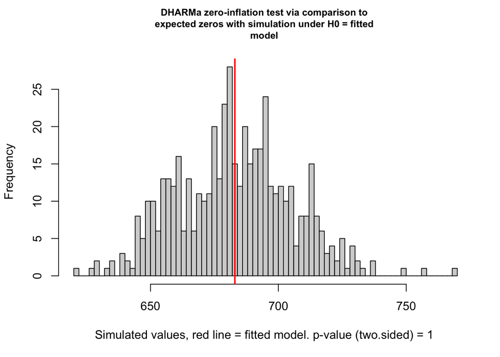

```
    DHARMa zero-inflation test via comparison to expected zeros with
    simulation under H0 = fitted model

data:  simulationOutput
ratioObsSim = 0.99928, p-value = 1
alternative hypothesis: two.sided
```

Upon using the hurdle and zero-inflated models, there are interesting findings. The NB2 and ZINB showed that the LRT value of the ZINB was higher than that of NB2 (χ² = 143.14, df = 7) (as they were nested models), showing the added complexity was worth it, as it is better fitting. As NB2, ZINB and hurdle models are not nested, they must be compared with AIC and BIC metrics. AIC was 2.44699^{4} for NB2, 2.43408^{4} for ZINB and 2.43304^{4} for the hurdle model, and the BIC values were 2.4521^{4}, 2.44366^{4} and 2.44263^{4}. It was shown that values for NM2 are the highest, followed by ZINB, then hurdle model values being the smallest, showing that it has the best predictive accuracy. Upon double checking the chosen, hurdle model, it is seen that the observed values are very well within the estimated values, supporting its ability as a model. For these aforementioned reasons, I chose to continue with the hurdle model.

# 6. Test and Probe Interaction

We now ask whether there may be an association between the number of chronic conditions a person has and the number of physician visits differing based off of sex?

## 6.1 Prediction

We predict that gender (male versus female) will moderate the direction of correlation such that females will create a more positive association than that of men. This means that there is a stronger positive correlation between the number of chronic conditions and the subsequent physician visits compared to that of men, who are predicted to have less of a positive correlation, if even negative.

## 6.2 Fitting the Interaction Model

```
 Family: nbinom2  ( log )
Formula:          visits ~ health + school + insurance + chronic * gender
Data: data

      AIC       BIC    logLik -2*log(L)  df.resid
  24471.9   24529.4  -12226.9   24453.9      4397


Dispersion parameter for nbinom2 family (): 1.16

Conditional model:
                      Estimate Std. Error z value Pr(>|z|)
(Intercept)           0.827166   0.062170  13.305  < 2e-16 ***
healthpoor            0.367655   0.048204   7.627 2.40e-14 ***
healthexcellent      -0.373779   0.061557  -6.072 1.26e-09 ***
school                0.027184   0.004403   6.174 6.64e-10 ***
insuranceyes          0.250309   0.040462   6.186 6.16e-10 ***
chronic               0.194411   0.018857  10.310  < 2e-16 ***
genderfemale          0.111451   0.049905   2.233   0.0255 *
chronic:genderfemale  0.002303   0.024147   0.095   0.9240
---
Signif. codes:  0 '***' 0.001 '**' 0.01 '*' 0.05 '.' 0.1 ' ' 1
```

## 6.3 Test whether the interaction is needed

We will be testing whether the interaction with gender improves the fit over the model

```
Data: data
Models:
neg_binom: visits ~ chronic + health + gender + school + insurance, zi=~0, disp=~1
interact: visits ~ health + school + insurance + chronic * gender, zi=~0, disp=~1
          Df   AIC   BIC logLik deviance  Chisq Chi Df Pr(>Chisq)
neg_binom  8 24470 24521 -12227    24454
interact   9 24472 24529 -12227    24454 0.0091      1     0.9241
```

This omnibus test reveals potential interactions between the variable of chronic conditions and gender. The χ² was 0.01, the df was 1 and the p-value was 0.92407. Adding the interaction showed very little benefit, if even a reduced predictive ability. The next few tests will show the possibilities of what probing might add.

## 6.4 Plot Predicted Counts

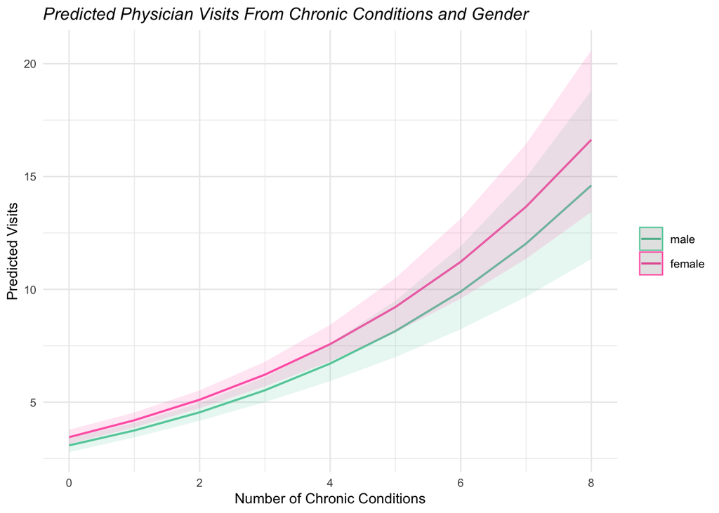

## 6.5 Probe the Interaction

Here we will find the slopes of the number of chronic conditions with gender and compare it against 0.

### Simple Slopes

```
 gender chronic.trend     SE  df asymp.LCL asymp.UCL
 male           0.194 0.0189 Inf     0.157     0.231
 female         0.197 0.0160 Inf     0.165     0.228

Results are averaged over the levels of: health, insurance
Confidence level used: 0.95
```

### Slope Comparison

```
 contrast      estimate     SE  df z.ratio p.value
 male - female  -0.0023 0.0241 Inf  -0.095  0.9240

Results are averaged over the levels of: health, insurance
```

### Simple Slopes Tested Against Zero

```
 gender chronic.trend     SE  df asymp.LCL asymp.UCL z.ratio p.value
 male           0.194 0.0189 Inf     0.157     0.231  10.310 <0.0001
 female         0.197 0.0160 Inf     0.165     0.228  12.300 <0.0001

Results are averaged over the levels of: health, insurance
Confidence level used: 0.95
```

The `pairs(slopes)` tests the interaction, but the sign flipped by changing the order of categories. The slopes do not differ, but the signs change.

### Simple Effects

Now flip it: the gender gap at low amounts of chronic conditions (−1 *SD*), average, and high (+1 *SD*) amounts of chronic conditions. We look at the gender difference at different chronic condition values, rather than the chronic conditions within each gender.

```
chronic = 0.192:
 gender response    SE  df asymp.LCL asymp.UCL
 male       3.55 0.150 Inf      3.27      3.86
 female     3.97 0.150 Inf      3.69      4.28

chronic = 1.542:
 gender response    SE  df asymp.LCL asymp.UCL
 male       4.62 0.152 Inf      4.33      4.93
 female     5.18 0.154 Inf      4.89      5.49

chronic = 2.892:
 gender response    SE  df asymp.LCL asymp.UCL
 male       6.00 0.246 Inf      5.54      6.51
 female     6.76 0.240 Inf      6.30      7.24

Results are averaged over the levels of: health, insurance
Confidence level used: 0.95
Intervals are back-transformed from the log scale
```

```
chronic = 0.192:
 contrast      estimate     SE  df z.ratio p.value
 male - female   -0.112 0.0464 Inf  -2.411  0.0159

chronic = 1.542:
 contrast      estimate     SE  df z.ratio p.value
 male - female   -0.115 0.0317 Inf  -3.629  0.0003

chronic = 2.892:
 contrast      estimate     SE  df z.ratio p.value
 male - female   -0.118 0.0445 Inf  -2.655  0.0079

Results are averaged over the levels of: health, insurance
Results are given on the log (not the response) scale.
```

**Simple Slopes** It can be seen that the slope different from the pairs() function being the differences betwen the male-female simple slopes, creating the interaction coefficient. However, when males are the reference group, it is female-male so that the estimate, standard error and p-value match, but the sign flips; they are both on the log scale. The sign is different simply because of flipped ordering of male and female in the different computations. Even though there are only two levels, there is only the comparison of two groups in the moderator, being male vs female, creating the interaction coefficient. **Simple Effects** The `emmeans()` counts differ, as they averages the predictors at the mean. However, `ggeffect()` hold these constant fixing them at a reference value (meaning, gender being male and health being average). We also used +/-1SD which is a decimal value, `ggplot()` uses whole numbers. The contrasts, being the male-female differences do not differ as it only depends on the gender coefficients (the two values of the moderator) not on other predictor values.

## 6.6 Report the simple effects in a table

Simple Effects of Gender Across Number of Chronic Conditions

Negative-binomial regression (log link)

| Chronic Conditions | Contrast | Log Contrast | SE | z | p |
| --- | --- | --- | --- | --- | --- |
| -1 SD | male - female | −0.112 | 0.046 | −2.411 | 0.016 |
| Mean | male - female | −0.115 | 0.032 | −3.629 | <0.001 |
| +1 SD | male - female | −0.118 | 0.044 | −2.655 | 0.008 |

Log contrasts = Men − Women. z-tests and p-values are computed on the log scale.

## 6.7 Interpret the Interaction

**Chronic Condition Association Differing by Gender?** Throughout the tests performed, the LRT found was extremely small(χ²(1) = 0.01, *p* = 0.924), and upon adding the interaction, showing that adding the interaction did not increase predictive ability/fit. Furthermore, when incorporating AIC & BIC, the fit was worse (AIC = 2.44719^{4} vs. 2.44699^{4} without the interaction; BIC = 2.45294^{4} vs. 2.4521^{4}). Furthermore, in assessing the log contrasts between males and females, they are so similar that differences between them and interaction with chronic conditions cannot be deduced, and there are no differences in slopes. Generally, men have lower numbers of visits as a whole, whoever this is simply a gender difference, rather than reflective of the impact of less chronic conditions.

**Confidence in the Interaction** Using the omnibus results and probing tests, some data was revealed, however it did not necessarily increase the confidence in the interaction, as our data reflects a lack of interaction between chronic condition and gender. Using various tests, such as information criteria, the omnibus test as well as additional probing have not been reflective of moderated effects. While there are gender differences present, none of the tests have provided adequate values to assume anything beyond purely gender differences, for example, the gap with omnibus test are fairly constant and parallel, rather than intersection.

# 7. Write Up & Discussion of Findings

### Model Selection

There were a few steps necessary to come to the final hurdle model. To begin, there was initial overdispersion found (mean = 5.77, variance = 45.69, 15.5% zeros). We initially verified whether a Gaussian, linear model may be appropriate, however it was not, which led to the use of 3 nested Poisson models (null, the addition of chronic, addition of all other predictors), finally selecting the most complex model, the “Full Poisson” before continuing. The Poisson model’s DHARMa yielded a dispersion ratio of (7.25 (*p* < .001) and a zero-inflation ratio of 15.03 (*p* < .001), which showed overdispersion and excess zeros, respectively. We then chose to fit a negative binomial model (NB2), and then compare the Poisson and NB2 through the LRT as they are nested models. The NB2 displayed an improved fit, with χ², df, p (1) = 1.212908^{4}, *p* < .001). The overdispersion was seemingly resolved with this model with a dispersion ratio of 1.04 (*p* = 0.432), and a zero-inflation ratio of 1.1 (*p* < .001). However there were excess zeros that the model had not accounted for, so we elected to employ both a zero-inflated and hurdle model. The hurdle model displayed the most predictive accuracy and was the most ideal model that reported a more adequate estimation of zeros.

## 7.2 Discussion

**References** Canadian Institute for Health Information. (2024, December 5). Access to primary care: Many Canadians face challenges. https://www.cihi.ca/en/primary-and-virtual-care-access-emergency-department-visits-for-primary-care-conditions/access-to-primary-care-many-canadians-face-challenges

Mobley, D., Baum, N. H., Beattie, A., & Nemeroff, C. (2019). When Imagination Becomes a Disease: Dealing With Hypochondriacal Patients in Clinical Practice. Ochsner journal, 19(2), 70–73. https://doi.org/10.31486/toj.18.0123

Queenan, J. A., Wong, S. T., Barber, D., Morkem, R., & Salman, A. (2021). The prevalence of common chronic conditions seen in Canadian primary care: Results from the Canadian Primary Care Sentinel Surveillance Network. Canadian Primary Care Sentinel Surveillance Network. https://cpcssn.ca/wp-content/uploads/2021/05/cpcssn-chronic-conditions-report-2021.pdf

Ross University School of Medicine. (2021, May 11). US vs. Canadian healthcare: What is the difference? https://medical.rossu.edu/about/blog/us-vs-canadian-healthcare